# How to be a good mentee and mentor

2021-04-06 10:42:03

## Motivation

- Having mentors can be important for your career/life advancement.
- Having mentees can be very fulfilling and worthwhile.

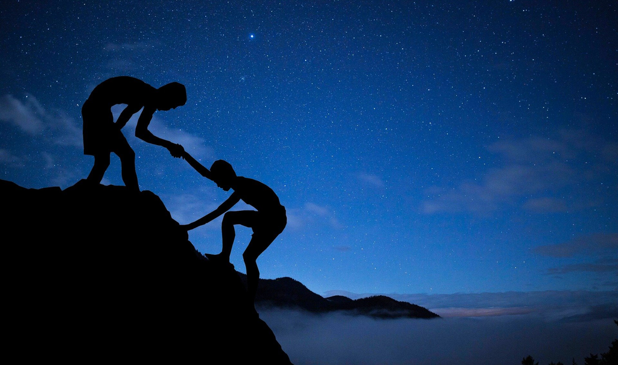

[Mohamed Hassan](https://pixabay.com/users/mohamed_hassan-5229782/)/Pixabay

## Being a good Mentee

## Start with the big picture

- Why do I want mentoring?
- How will a certain mentoring relationship fit my overall (career/life) plans?

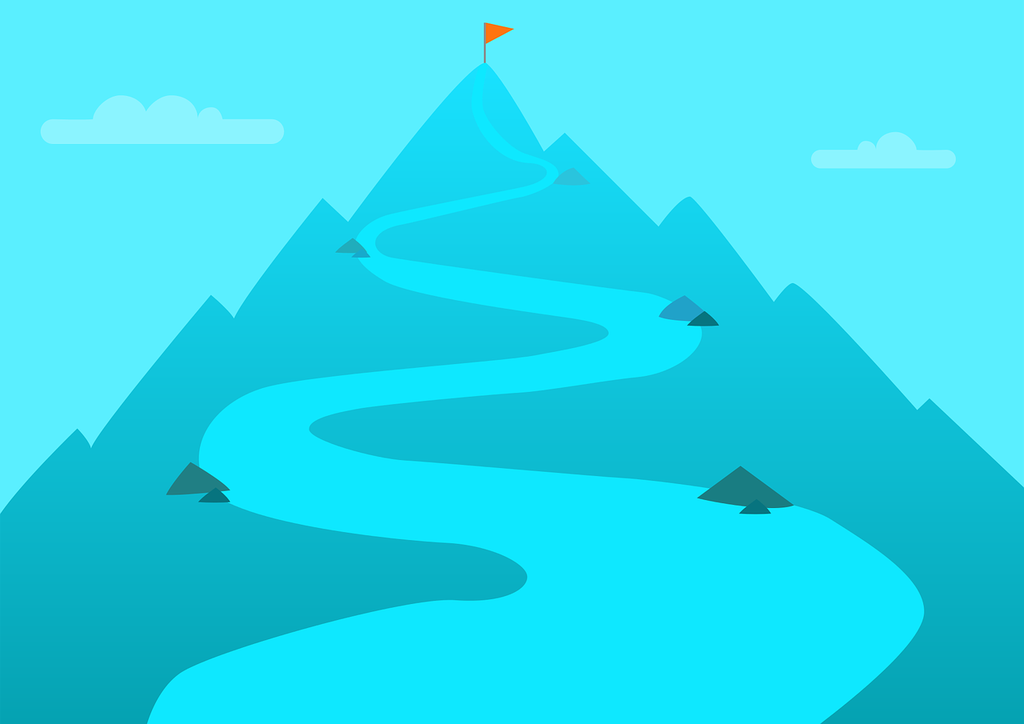

[ijmaki](https://pixabay.com/users/ijmaki-1797813/)/Pixabay

What is your *big picture*? How do your current mentors fit? What kind of mentors are you missing?

## Figure out your needs

- Determine in which areas you want mentorship.
- Determine the goals you have for the mentoring relationship.
- Determine what kind of mentorship you want (formal/informal, often/occasional, etc.).

Do you have any examples you are willing to share?

## Decide on the level of formality

- You can have mentorships which are [explicit and formal](https://grad.uga.edu/index.php/current-students/mentor-mentee-compacts/).
- You can have mentorsips which are explicit but informal.
- You can have mentorships which are implicit and informal.

What types of mentors/mentorships do you currently have?

## Assemble your team

- Figure out individuals that can make for good mentors.
- Determine if you want/need specific mentor characteristics (experience/age/gender/occupation/etc).
- For each mentor/mentorship relation, decide on the setup you want.
- Ask individuals to be your mentors (or don’t).

If you have current mentors, how did you aquire them?

## Be proactive

- Your mentors are likely busy and while they hopefully are committed to you, you are not constantly on their minds.
- You need to check in with mentors as agreed upon.
- You need to ask for specifics you want.
- You should set the direction of the conversation, the topics covered and not covered, etc.
- In some way, consider yourself the **leader** of the mentorship.

Do you have any examples you are willing to share that illustrate (not) being the driver of a mentorship?

## Be prepared

- Have an agenda (explicit or implicit) for your meetings.
- Set the stage, give context: Don’t assume your mentor has thought much about you or your questions before you meet.
- Refrain from vague *what should I do?* questions. Provide your detailed thoughts, ask for specific input.
- Guide your mentor toward the input you want/need.

What are examples of good/bad preparation?

## Put in the work

- Meet as agreed.
- Be fully attentive during your meetings, try to soak up everything. You don’t have to agree, but you should let it sink in.
- Do whatever *homework* you agreed on doing.

Any examples you are willing to share of *doing the work* as part of a mentorship?

## Be reflective

- Carefully consider the mentor’s thoughts, even (or especially) if they surprise you.
- Getting a *second opinion* is a good idea.
- Your mentor is hopefully experienced, but they can be wrong.
- Some things work for some people, not others. Consider if the advice can work for you.

Any examples you are willing to share of good/bad advice you received from a mentor?

## Be professional

- Respect the constraints (e.g. topics, time) that you agreed on.
- Keep conversations confidential.
- Ensure the mentorship does not lead to (perceived) unfair treatment of you by your mentor.
- Avoid drifting toward a setup that is different from the one initially decided on (e.g. becoming friends). If you notice this happening, discuss it explicitly and decide what to do.

## Be aware

- Both you and your mentor are humans, with shortcomings. Be aware of them. Ensure they do not get in the way.
- If your mentor tries to turn you into a Mini-Me version of them, call them out and if necessary, end mentorship.
- If you cannot take the mentor’s advice because of some deeper issues (they are too much like one of your parents who you resent, etc.), be aware and address.
- Be especially aware around power/romantic/sexual tensions, address quickly.

Any examples you are willing to share where *being aware* was crucial in a mentorship?

## Being a good Mentor

## Start with the big picture

- Why do I want to mentor?
- How will a certain mentoring relationship fit my overall (career/life) plans?

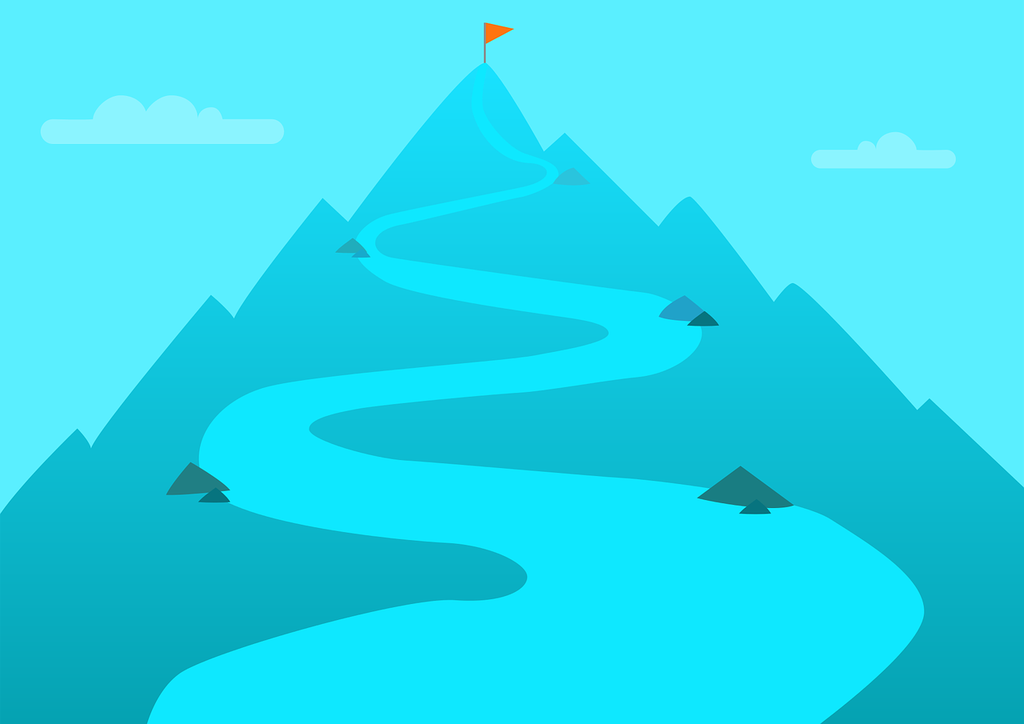

[ijmaki](https://pixabay.com/users/ijmaki-1797813/)/Pixabay

What is your *big picture*? How do your mentees fit? What kind of mentorships do you (not) want to have?

## Know your limits

- Be aware of your time/energy limitations.
- Only take on mentees if you can fully commit.
- Don’t try to provide mentorship in areas where you think you don’t have the right expertise.
- **But: You might have more to offer than you think!**
- If you think you can’t help, connect your mentees with people who might.

Are there any areas where you could serve as mentor that you might not have thought about before?

## Set expectations

- Ask the mentee what they are looking for.
- Be upfront about what you can and cannot provide.
- Set clear expectations regarding time commitment, areas the mentorship will cover, etc.
- Consider creating a (public) *group member/mentee handbook*. ([Example.](https://cobeylab.github.io/lab_handbook/))

Do you have any mentor experience and how did you handle *expecations*?

## Be available and reliable

- Once you committed to being a mentor to someone, be available within the agreed upon framework.
- Keep appointments as much as possible, consider this a high priority activity.
- During meetings, be fully present (put your phone away).
- Outside meetings, respond to mentee requests in a reliable manner (within the agreed framework).

## Stay in the background

- **It’s not about you.**
- Listen much more than talk.
- Be interested in fully understanding your mentee and their questions.
- Mainly provide input as requested.
- Occasional *leading/suggesting* is ok.

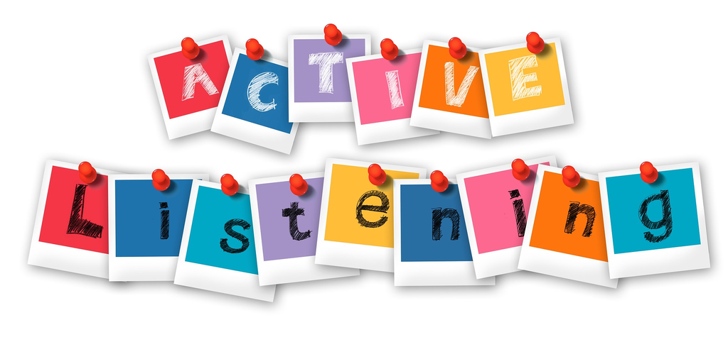

[Gerd Altmann](https://pixabay.com/users/geralt-9301/)/Pixabay

## Be honest but encouraging

- Criticism is ok, but it needs to be part of overall encouragement and support.
- You are not a teacher/grader, you are a mentor (coach/cheerleader/helper).
- Encourage your mentee to take initiative, both as part of the mentorship and outside.
- If you find your mentee is not *living up*, address that in a direct and supportive manner instead of constant nagging/criticism during meetings.

## Be trustworthy

- Mentoring relationships should have a certain level of confidentiality.
- If in doubt, keep it to yourself.
- Be clear about topics you don’t want (or cannot) keep confidential.
- Do what you preach. You can’t be a good mentor unless you lead by example.

## Be explicit

- Don’t assume anything. Spell out details, provide context. Explain *unspoken* rules of the profession.
- If there is anything in the mentoring relationship that seems not addressed, talk about it.

Do you have any examples you are willing to share where *being explicit* was handled (not) well?

## Be aware

- It goes without saying that you need to hold yourself to the highest ethical standards.
- Don’t try to live your dreams through your mentees. **It’s not about you.**
- Be aware if/when your mentee starts outgrowing you, change mentorship as needed.
- Be especially aware around power/romantic/sexual tensions, address quickly.

## Get training and help

- As you move into leadership positions, seek any training you feel you need.
- If you have mentors yourself, discuss with them any challenges.
- Even if you don’t have formal mentors, do reach out for help to others if you think you can use it.

## Further Resources

- [Short article on finding mentors](https://science.sciencemag.org/content/371/6536/1398)
- [Nice short read on how to manage your adviser](https://www.nature.com/articles/nj7331-570a)
- [How to develop a mentor–mentee document (for mentors).](https://doi.org/10.1371/journal.pcbi.1005709)
- [The Elements of Mentoring](https://amzn.to/389huE4) - ok book with some tips on mentoring, mainly for mentors
- [U Michigan website with mentoring content](https://rackham.umich.edu/faculty-and-staff/resources-for-directors/mentoring/) - good links to resources